# Racing the Data: An LLM-Assisted Exploratory Analysis of the 2024 NYC Marathon

## Exploratory Data Analysis

After data wrangling, a cleaner dataset is used for Exploratory Data Analysis. In this section, we focus on answering three of our top research questions:

1. **Age and performance**:
- when do runners achieve peak performance?
- how do older runners compare to younger runners relative to age group?
2. **Experience and performance**:
- does prior race experience correspond to better finish times and age-graded results?
3. **Geographic patterns**:
- how international is the NYC Marathon field
- which U.S. states produce the fastest runners in this sample?

### Age and performance

**1.1. Peak performance by age**

```r
age_perf <- nyc_marathon_cleaned %>%
  filter(!is.na(age)) %>%
  group_by(age) %>%
  summarise(
    runners = n(),
    avg_time = mean(OverallTime_min, na.rm = TRUE),
    avg_age_grade = mean(ageGradePercent, na.rm = TRUE)
  ) %>%
  filter(runners >= 10)

best_ages <- age_perf %>% arrange(avg_time) %>% slice_head(n = 5)

best_ages %>% kable(caption = "Best average finish times by age")
```

Best average finish times by age

| age | runners | avg_time | avg_age_grade |
| --- | --- | --- | --- |
| 28 | 2053 | 259.4848 | 51.84245 |
| 24 | 1282 | 260.8324 | 51.61279 |
| 26 | 1907 | 261.0959 | 51.60920 |
| 25 | 1646 | 261.5995 | 51.41074 |
| 27 | 1996 | 261.8500 | 51.29671 |

> Calculating average finish time and average age-grade by exact age, then extracts the fastest ages. It provides the base summary for the age-performance discussion.

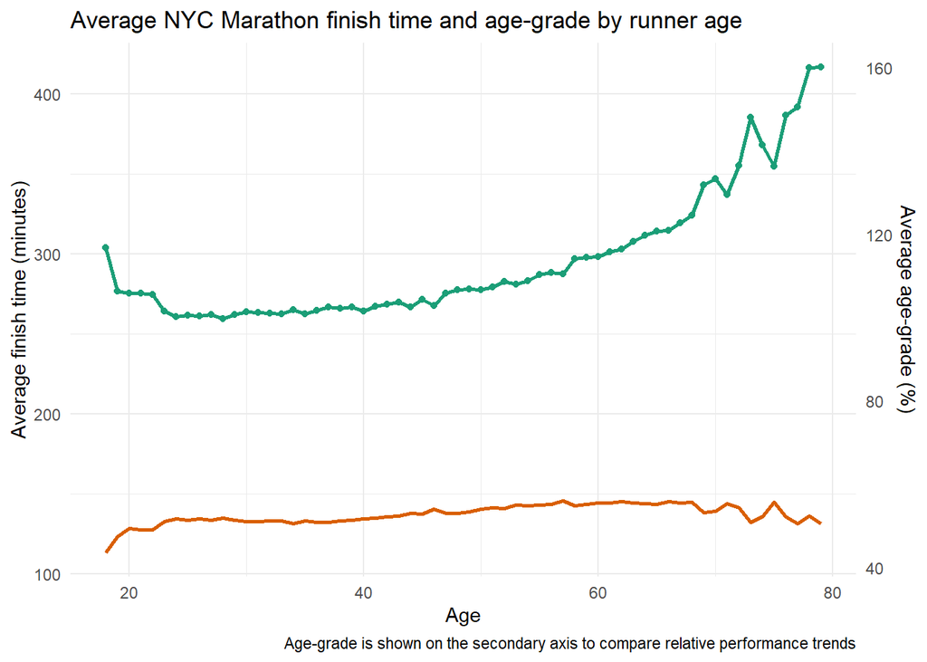

```r
age_perf %>%
    ggplot(aes(x = age)) +
    geom_line(aes(y = avg_time), color = "#1b9e77", size = 1) +
    geom_point(aes(y = avg_time), color = "#1b9e77", size = 1.5) +
    geom_line(aes(y = avg_age_grade * 2.6), color = "#d95f02", size = 1) +
    scale_y_continuous(
        name = "Average finish time (minutes)",
        sec.axis = sec_axis(~ . / 2.6, name = "Average age-grade (%)")
    ) +
    labs(
        title = "Average NYC Marathon finish time and age-grade by runner age",
        x = "Age",
        caption = "Age-grade is shown on the secondary axis to compare relative performance trends"
    ) +
    theme_minimal()
```

> The chart above shows that the fastest average finish times occur in the **late 20s to early 30s**. In this dataset, the lowest average times are concentrated around **ages 24-29**.

**1.2. Relative performance by age group**

```r
age_group_perf <- nyc_marathon_cleaned %>%
    group_by(age_group) %>%
    summarise(
        runners = n(),
        avg_time = mean(OverallTime_min, na.rm = TRUE),
        avg_age_grade = mean(ageGradePercent, na.rm = TRUE)
    ) %>%
    arrange(avg_time)

age_group_perf %>% kable(caption = "Average finish time and age-grade by age group")
```

Average finish time and age-grade by age group

| age_group | runners | avg_time | avg_age_grade |
| --- | --- | --- | --- |
| 20-29 | 12521 | 262.2311 | 51.32547 |
| 30-39 | 16500 | 264.2047 | 51.05305 |
| 40-49 | 13684 | 270.1733 | 52.66645 |
| 50-59 | 9277 | 284.3896 | 54.72990 |
| Under 20 | 155 | 286.1026 | 46.07368 |
| Over 60 | 3375 | 315.6987 | 55.15650 |

> Summarazing groups runners into broader age bands and comparing their average finish times and age-graded scores. It is useful for seeing broader life-stage patterns instead of only exact ages.

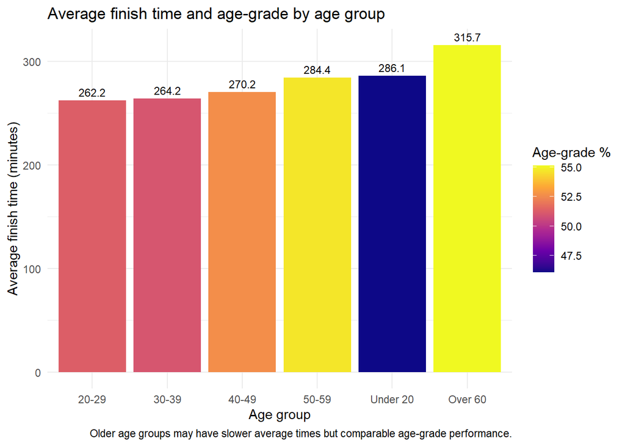

```r
age_group_perf %>%
    ggplot(aes(x = fct_reorder(age_group, avg_time), y = avg_time, fill = avg_age_grade)) +
    geom_col() +
    geom_text(aes(label = round(avg_time, 1)), vjust = -0.5, size = 3) +
    scale_fill_viridis_c(option = "plasma", name = "Age-grade %") +
    labs(
        title = "Average finish time and age-grade by age group",
        x = "Age group",
        y = "Average finish time (minutes)",
        caption = "Older age groups may have slower average times but comparable age-grade performance."
    ) +
    theme_minimal()
```

> Older runners tend to have slower absolute finish times, but **their age-graded scores remain competitive across groups**. This suggests that age-group-adjusted performance is strong even when raw finish time declines.

### Experience and performance

**2.1. Races count and average finish time**

```r
experience_perf <- nyc_marathon_cleaned %>%
    filter(!is.na(racesCount)) %>%
    group_by(racesCount) %>%
    summarise(
        runners = n(),
        avg_time = mean(OverallTime_min, na.rm = TRUE),
        avg_age_grade = mean(ageGradePercent, na.rm = TRUE)
    ) %>%
    filter(runners >= 20)

experience_perf %>% filter(racesCount == 1 | racesCount %% 5 == 0) %>%  kable(caption = "Avg finish time by number of NYRR races completed")
```

Avg finish time by number of NYRR races completed

| racesCount | runners | avg_time | avg_age_grade |
| --- | --- | --- | --- |
| 1 | 26384 | 268.3918 | 52.84633 |
| 5 | 829 | 263.2154 | 54.55462 |
| 10 | 1201 | 277.3992 | 49.29443 |
| 15 | 507 | 278.5755 | 49.98394 |
| 20 | 477 | 271.4029 | 51.52897 |
| 25 | 310 | 282.4035 | 49.87932 |
| 30 | 221 | 270.8190 | 52.28380 |
| 35 | 160 | 286.8072 | 51.13325 |
| 40 | 123 | 271.4011 | 52.29594 |
| 45 | 107 | 278.3952 | 52.08047 |
| 50 | 70 | 276.7906 | 52.78171 |
| 55 | 66 | 276.5573 | 52.76742 |
| 60 | 68 | 272.5963 | 53.39235 |
| 65 | 54 | 281.5011 | 52.27611 |
| 70 | 40 | 295.2758 | 51.56150 |
| 75 | 44 | 272.3743 | 53.80250 |
| 80 | 48 | 279.3242 | 52.05271 |
| 85 | 36 | 268.3814 | 54.79556 |
| 90 | 26 | 288.6919 | 52.28115 |
| 95 | 20 | 285.3045 | 52.39450 |
| 100 | 24 | 287.7325 | 49.66750 |
| 110 | 26 | 322.0788 | 48.95654 |

> Summarizing performance by every 5 race counts. It helps reveal whether experience is linked to faster finish times.

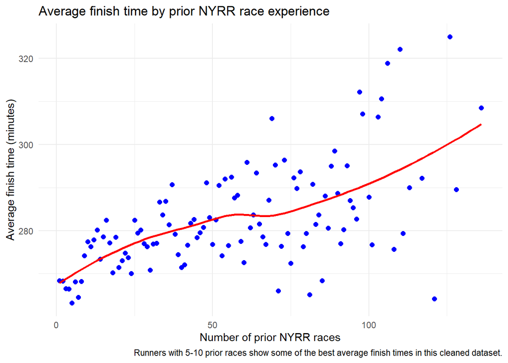

```r
experience_perf %>%
    ggplot(aes(x = racesCount, y = avg_time)) +
    geom_point(color = "blue", size = 2) +
    geom_smooth(method = "loess", se = FALSE, color = "red") +
    labs(
        title = "Average finish time by prior NYRR race experience",
        x = "Number of prior NYRR races",
        y = "Average finish time (minutes)",
        caption = "Runners with 5-10 prior races show some of the best average finish times in this cleaned dataset."
    ) +
    theme_minimal()
```

> Showing the relationship between race count and finish time. **Pattern doesn´t seem to be linear**

**2.2. Experience categories and performance**

```r
marathon_exp_perf <- nyc_marathon_cleaned %>%
    group_by(runner_exp) %>%
    summarise(
        runners = n(),
        avg_time = mean(OverallTime_min, na.rm = TRUE),
        avg_age_grade = mean(ageGradePercent, na.rm = TRUE)
    ) %>%
    arrange(avg_time)

marathon_exp_perf %>% kable(caption = "Performance by race experience category")
```

Performance by race experience category

| runner_exp | runners | avg_time | avg_age_grade |
| --- | --- | --- | --- |
| Experienced runner | 9431 | 267.6991 | 53.23961 |
| First-time runner | 26384 | 268.3918 | 52.84633 |
| Golden runner | 4217 | 270.2793 | 52.25267 |
| Master runner | 15480 | 280.5070 | 51.03251 |

> Converting race counts into named experience categories. It makes the discussion easier to read because the groups are more interpretable than raw counts.

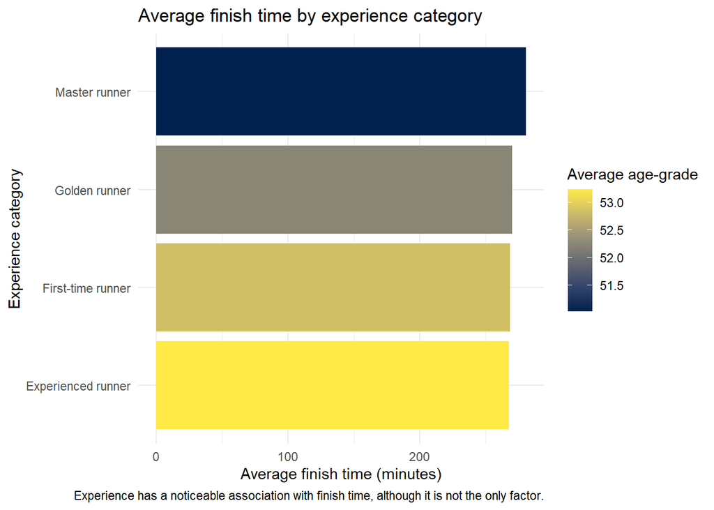

```r
marathon_exp_perf %>%
    ggplot(aes(x = fct_reorder(runner_exp, avg_time), y = avg_time, fill = avg_age_grade)) +
    geom_col() +
    coord_flip() +
    scale_fill_viridis_c(option = "cividis", name = "Average age-grade") +
    labs(
        title = "Average finish time by experience category",
        x = "Experience category",
        y = "Average finish time (minutes)",
        caption = "Experience has a noticeable association with finish time, although it is not the only factor."
    ) +
    theme_minimal()
```

```r
marathon_exp_perf_2 <- nyc_marathon_cleaned %>%
    group_by(runner_exp) %>% filter(age_group == "20-29") %>%
  summarise(
        runners = n(),
        avg_time = mean(OverallTime_min, na.rm = TRUE)
  ) %>%
    arrange(avg_time)

marathon_exp_perf_2 %>% kable(caption = "Performance by race experiene in the 20-29 age group")
```

Performance by race experiene in the 20-29 age group

| runner_exp | runners | avg_time |
| --- | --- | --- |
| Experienced runner | 2190 | 257.5798 |
| Golden runner | 1245 | 261.6394 |
| First-time runner | 6453 | 263.0565 |
| Master runner | 2633 | 264.3568 |

> After race experience inspection, I wanted to look at runner experience at a specific age group (**20-29**) to see if having racing experience actually improves performance. As expected, **Experienced and Golden runners performed better than first-time runners**. On the other hand, I still observe that Master runners perform the worst in average. My main guess is that they just run for fun, joining the most amount of races as possible.

### 3. Geographic patterns

**3.1. International participation**

```r
country_summary <- nyc_marathon_cleaned %>%
    count(countryCode, sort = TRUE) %>%
    mutate(pct = n / sum(n) * 100)

country_summary %>% slice_head(n = 12) %>%
    kable(caption = "Top countries by participant count")
```

Top countries by participant count

| countryCode | n | pct |
| --- | --- | --- |
| USA | 37695 | 67.9042369 |
| ITA | 2345 | 4.2243119 |
| FRA | 1966 | 3.5415766 |
| GBR | 1742 | 3.1380602 |
| DEU | 1236 | 2.2265456 |
| MEX | 1065 | 1.9185041 |
| NLD | 876 | 1.5780372 |
| CAN | 823 | 1.4825623 |
| AUS | 710 | 1.2790027 |
| BRA | 677 | 1.2195561 |
| ESP | 609 | 1.0970601 |
| CHE | 476 | 0.8574723 |

```r
country_summary %>%
    summarise(
        total_countries = n(),
        total_runners = sum(n),
        usa_runners = sum(if_else(countryCode == "USA", n, 0L)),
        international_runners = total_runners - usa_runners,
        international_pct = international_runners / total_runners * 100
    ) %>%
    kable(caption = "International composition of the field")
```

International composition of the field

| total_countries | total_runners | usa_runners | international_runners | international_pct |
| --- | --- | --- | --- | --- |
| 136 | 55512 | 37695 | 17817 | 32.09576 |

> As expected, the NYC Marathon dataset shows a **strong dominance of U.S. runners**. However, we can observe that **17,817 runners (32.1%) come from international locations across 136 countries**. The top international countries are primarily from Europe (Italy, France and U-K. among the most frequent).

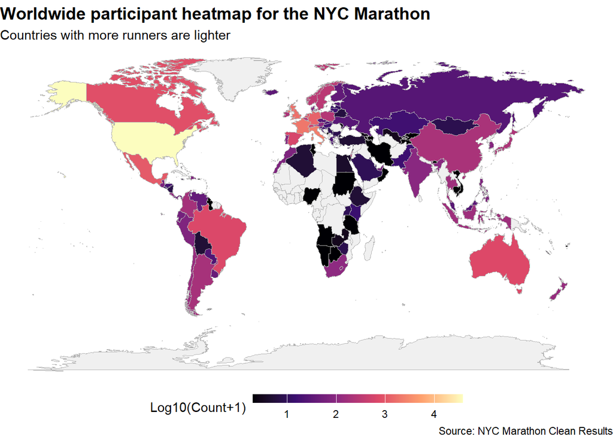

```r
library(countrycode)
library(maps)

world_map <- map_data("world") %>%
    mutate(region = tolower(region))

country_summary_fixed <- country_summary %>%
    mutate(
        region = countrycode(countryCode, "iso3c", "country.name"),
        region = case_when(
            region == "United States" ~ "usa",
            region == "United Kingdom" ~ "uk",
            region == "Czechia" ~ "czech republic",
            TRUE ~ tolower(region)
        )
    )

world_plot_data <- world_map %>%
    left_join(country_summary_fixed %>% select(region, n), by = "region")

ggplot(world_plot_data, aes(long, lat, group = group, fill = log10(n + 1))) +
    geom_polygon(color = "gray70", size = 0.15) +
    scale_fill_viridis_c(
        option = "magma",
        na.value = "#f0f0f0",
        name = "Log10(Count+1)",
        guide = guide_colorbar(barwidth = 12, barheight = 0.5)
    ) +
    labs(
        title = "Worldwide participant heatmap for the NYC Marathon",
        subtitle = "Countries with more runners are lighter",
        x = "",
        y = "",
        caption = "Source: NYC Marathon Clean Results"
    ) +
    theme_void() +
    theme(
        legend.position = "bottom",
        plot.title = element_text(face = "bold", size = 14),
        plot.subtitle = element_text(size = 11)
    )
```

> The world map above highlights the global spread of the NYC Marathon field, showing the countries with more participants in lighter colors.

**3.2. Fastest U.S. states**

```r
state_lookup <- tibble(
    stateProvince = state.abb,
    region = tolower(state.name)
)

us_state_perf <- nyc_marathon_cleaned %>%
    filter(countryCode == "USA", !is.na(stateProvince)) %>%
    group_by(stateProvince) %>%
    summarise(
        runners = n(),
        avg_time = mean(OverallTime_min, na.rm = TRUE)
    ) %>%
    filter(runners >= 100) %>%
    arrange(avg_time) %>%
    left_join(state_lookup, by = "stateProvince")

us_state_perf %>% slice_head(n = 10) %>%
    kable(caption = "Top 10 fastest U.S. states by average finish time")
```

Top 10 fastest U.S. states by average finish time

| stateProvince | runners | avg_time | region |
| --- | --- | --- | --- |
| UT | 182 | 254.8560 | utah |
| CO | 436 | 255.2944 | colorado |
| OR | 157 | 255.3660 | oregon |
| MI | 195 | 258.7615 | michigan |
| WA | 317 | 261.2940 | washington |
| DC | 211 | 261.3332 | NA |
| MN | 175 | 263.0974 | minnesota |
| WI | 119 | 266.3271 | wisconsin |
| MA | 1287 | 266.8218 | massachusetts |
| IN | 130 | 267.3777 | indiana |

> Comparing U.S. states using average finish time, while restricting the analysis to states with enough runners (more than 100) to be meaningful.

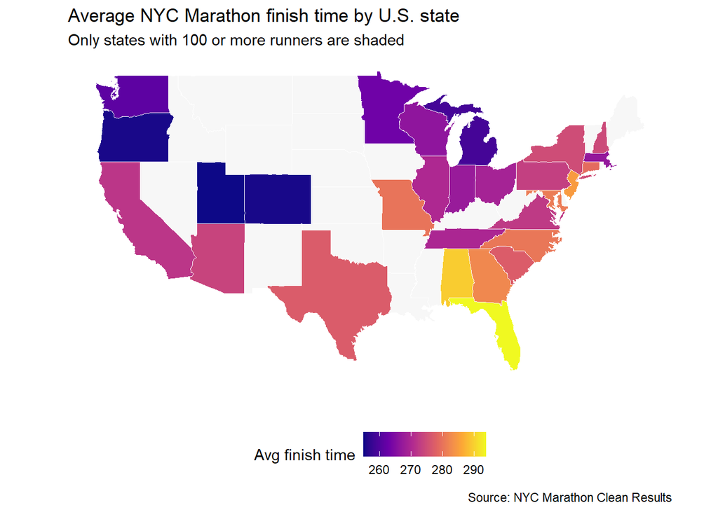

```r
state_map <- map_data("state")
state_map <- state_map %>%
    left_join(us_state_perf, by = "region")

state_map %>%
    ggplot(aes(long, lat, group = group, fill = avg_time)) +
    geom_polygon(color = "white", size = 0.15) +
    coord_fixed(1.3) +
    scale_fill_viridis_c(
        option = "plasma",
        na.value = "#f7f7f7",
        name = "Avg finish time"
    ) +
    labs(
        title = "Average NYC Marathon finish time by U.S. state",
        subtitle = "Only states with 100 or more runners are shaded",
        x = "",
        y = "",
        caption = "Source: NYC Marathon Clean Results"
    ) +
    theme_minimal() +
    theme(
        axis.text = element_blank(),
        axis.ticks = element_blank(),
        panel.grid = element_blank(),
        legend.position = "bottom"
    )
```

> As observed in the map, the fastest state averages are led by **Utah, Colorado, and Oregon**, which may reflect strong training cultures, altitude adaptation, or selection of fast runners from those regions.

```r
nyc_marathon_cleaned %>%
    filter(stateProvince == "FL") %>%
    summarise(
        runners = n(),
        avg_age = mean(age),
        avg_overallTime = mean(OverallTime_min)
    )
```

```
## # A tibble: 1 × 3
##   runners avg_age avg_overallTime
##     <int>   <dbl>           <dbl>
## 1     974    41.5            294.
```

> On the other hand, we can observe how **Florida is one of the states with the slowest runners**. This might be due to the **amount of runners** (higher than the average per state), or the **age of the participants** (Florida is known for having an older population).

### Tableau visualizations and comparison with R

To complement the R plots, I have also created Tableau maps using the *nyc_marathon_cleaned* dataset. These visuals emphasize interactivity and quick geographic storytelling:

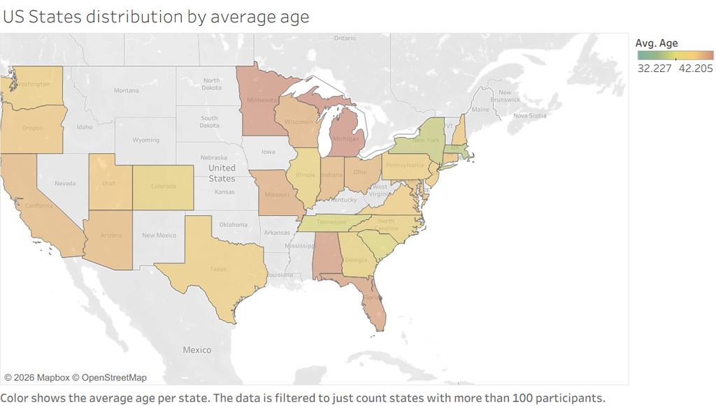

> I wanted to look at the average age per state to confirm that **Florida along Minnesota and Michigan had the highest age averages.**

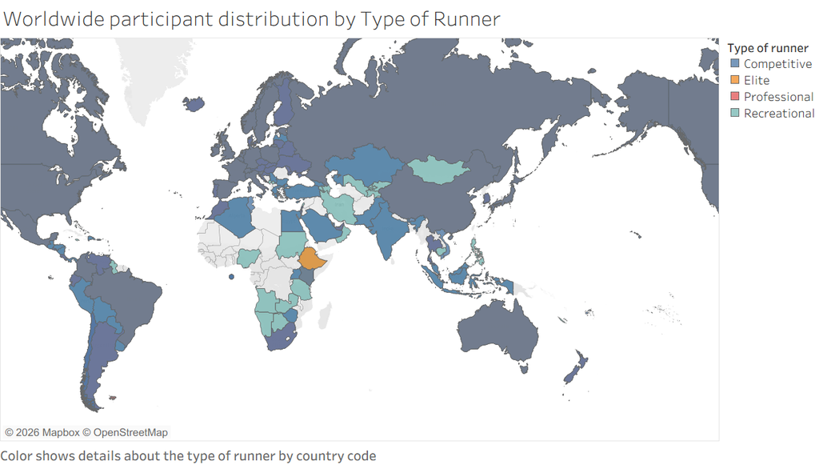

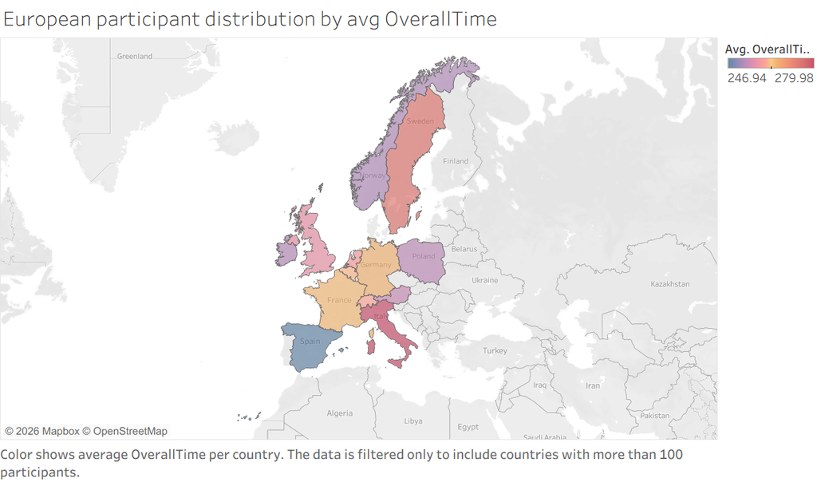

> As a good european citizen, I wanted to look at performance by european country. Surprisingly, **Spain showed the lowest average Overall Time**, which means that we were the fastest european country in the 2024 NYC Marathon (Vamos!!!).

**Quick Reflexion:**

After working with both R and Tableau, I found that Tableau is especially powerful for fast, interactive visualizations. It makes filtering, slicing, and exploring data very intuitive when the goal is to build or iterate on plots quickly. R, however, is stronger for rigorous statistical transformation and reproducible analysis, which makes it the better tool for deeper analytical work.

## LLM Integration & Discussion

LLMs were integrated as coding and reasoning assistants during both Data Wrangling (DW) and Exploratory Data Analysis (EDA). The main model used was **GPT-5.3** (OpenAI 2026) through **Copilot Pro in Visual Studio Code** (GitHub Copilot 2026; Microsoft 2026). In practice, Copilot was used to accelerate repetitive coding tasks, propose transformation logic, and help structure exploratory analyses, while final decisions remained under human control.

### Prompting strategies

Two prompting strategies were especially useful in this workflow:

1. **Chain-of-thought style prompting (process-focused prompts)**
   - Prompts asked the model to reason step-by-step before generating code (for example: *inspect schema -> identify potential anomalies -> propose cleaning rules -> provide R code*).
   - This improved transparency and made it easier to detect logic errors before execution.
2. **Few-shot prompting (example-guided prompts)**
   - Small examples of desired transformations were provided, then the model was asked to generalize (for example, *create a engineered feature called “age_group” by using the variable “age”. The format is the following: age < 20, then “Under 20” or age >= 20 & age < 30, then “20-29”*).
   - This was useful for keeping goals clear as LLMs sometimes don´t generate what you want.

Additional prompt controls that improved quality included explicit constraints such as **“use tidyverse only”, “explain step by step”, or “document the code.”**

### LLM-assisted workflow pipeline

The operational pipeline used for the DW tasks was:

**Raw Dataset -> LLM detects anomalies -> LLM suggests tasks -> LLM generates code -> human verifies everything -> R executes transformations -> clean dataset**

In implementation terms:

1. The raw NYC Marathon file was loaded and profiled in R.
2. GPT-5.3/Copilot flagged potential issues (time format consistency, missingness patterns, redundant variables, category design opportunities).
3. The model proposed a prioritized task list for cleaning and enrichment.
4. The model generated candidate R/tidyverse code.
5. The analyst reviewed each step for semantic correctness and domain plausibility.
6. Only validated code was executed in R.
7. Outputs were re-checked with summary statistics, missing-value audits, and spot inspections before exporting the final cleaned CSV.

This **human-in-the-loop structure** ensured that LLM assistance increased speed without bypassing analytical validation.

### Feedback and limitations

**What worked well:**

- **Speed and productivity:** GPT-5.3 in Copilot Pro reduced the time required to draft repetitive wrangling code and plotting scaffolds.
- **Documentation support:** It helped convert technical transformations into report-ready explanations.

**Observed limitations:**

- **Occasional semantic drift:** Some suggestions can misinterpret variable meaning (for example, initially reading `racesCount` as NYC Marathon participations rather than NYRR-system races).
- **Overconfident outputs:** The model may present plausible but incorrect assumptions unless prompts enforce verification.
- **Prompt sensitivity:** Output quality depends strongly on precise instructions, constraints, and examples.

Overall, the Large Language Model performed best as an accelerator for coding and structured exploration, not as an autonomous analyst. This is aligned with evidence in prior work that LLMs can substantially support data preparation workflows, but still require careful human validation (Jaimovitch-López et al. 2023; Liu et al. 2024; Zhou et al. 2025; Akella and Narayanam 2025).

## Conclusion

This project used an LLM-assisted workflow to clean, enrich, and explore the 2024 NYC Marathon results. The wrangling stage standardized time variables, handled missing values, removed redundant fields, and created interpretable features for age, experience, and performance type. The exploratory analysis then showed that peak raw performance is concentrated in the late 20s and early 30s, that moderate race experience is associated with strong results, and that the field is both geographically diverse and strongly international.

From a methodological perspective, the project shows that LLMs can be useful collaborators in data wrangling and analysis planning when they are kept inside a human-validated workflow. They are most valuable for accelerating transformation design, structuring exploratory ideas, and drafting analysis narratives. The final analytical conclusions, however, still come from the cleaned data and the checks performed in R.

## References

Akella, Ashlesha, and Krishnasuri Narayanam. 2025. “Data Wrangling Task Automation Using Code-Generating Language Models.” In *Proceedings of the AAAI Conference on Artificial Intelligence*, 39:29616–18. 28. https://doi.org/10.1609/aaai.v39i28.35344.

GitHub Copilot. 2026. “Copilot Pro.” Online service. https://github.com/features/copilot.

Hunter, Sandra K., and Alyssa A. Stevens. 2013. “Sex Differences in Marathon Running with Advanced Age.” *Medicine and Science in Sports and Exercise* 45 (1): 148–56. https://doi.org/10.1249/MSS.0b013e31826900f6.

Jaimovitch-López, Gonzalo, Cèsar Ferri, José Hernández-Orallo, Fernando Martínez-Plumed, and María José Ramírez-Quintana. 2023. “Can Language Models Automate Data Wrangling?” *Machine Learning* 112: 2053–82. https://doi.org/10.1007/s10994-022-06259-9.

Jokl, P, P. M. Sethi, and A. J. Cooper. 2004. “Master’s Performance in the New York City Marathon 1983-1999.” *British Journal of Sports Medicine* 38 (4): 408–12. https://doi.org/10.1136/bjsm.2002.003566.

Liu, Lei, So Hasegawa, Shailaja Keyur Sampat, Maria Xenochristou, Wei-Peng Chen, and Takashi Kato. 2024. “AutoDW: Automatic Data Wrangling Leveraging Large Language Models.” In *Proceedings of the 39th IEEE/ACM International Conference on Automated Software Engineering*.

Microsoft. 2026. “Visual Studio Code.” Software application. https://code.visualstudio.com.

New York Road Runners. 2024. “NYRR Results: New York City Marathon Official Results.” https://results.nyrr.org.

OpenAI. 2026. “GPT-5.” Online service. https://openai.com.

Vitti, Ambra, Pantelis T. Nikolaidis, Elias Villiger, Vincent Onywera, and Beat Knechtle. 2019. “The "New York City Marathon": Participation and Performance Trends of 1.2M Runners During Half-Century.” *Research in Sports Medicine* 28 (1): 121–37. https://doi.org/10.1080/15438627.2019.1586705.

Zhou, Wei, Jun Zhou, Haoyu Wang, Zhenghao Li, Qikang He, Shaokun Han, Guoliang Li, Xuanhe Zhou, and Yeye He. 2025. “Can LLMs Clean up Your Mess? A Survey of Application-Ready Data Preparation with LLMs.” *IEEE Transactions on Knowledge and Data Engineering*.